# water access for refugees and americans

Brendan Sullivan

October 18, 2019

## Data exploration

#### Borehole access

1663 observations, high NA population. Variables with around 50% or less NA’s could yield good info.

Numerical variables of interest:

- Elevation in meters above sea level
- Depth in m
- Static water level in meters below ground level
- Casing diameter in inch
- Driller’s yield in m3/hr
- Daily pumping time in h

Look at categorical variables like:

- Country
- Drilling date
- Status

```r
summary(borehole_access)
```

```
##      Iso3             Country            Site ID
##  Length:1663        Length:1663        Length:1663
##  Class :character   Class :character   Class :character
##  Mode  :character   Mode  :character   Mode  :character
##
##
##
##
##   Site name         Borehole name      Automatic Borehole ID
##  Length:1663        Length:1663        Length:1663
##  Class :character   Class :character   Class :character
##  Mode  :character   Mode  :character   Mode  :character
##
##
##
##
##  Local Borehole ID     Latitude         Longitude
##  Length:1663        Min.   :-21.072   Min.   :-8.067
##  Class :character   1st Qu.:  1.146   1st Qu.:20.768
##  Mode  :character   Median :  3.379   Median :31.083
##                     Mean   :  3.732   Mean   :26.861
##                     3rd Qu.:  8.164   3rd Qu.:31.960
##                     Max.   : 34.664   Max.   :88.075
##
##  Elevation in meters above sea level    Status          Drilling date
##  Min.   :  25.0                      Length:1663        Length:1663
##  1st Qu.: 434.5                      Class :character   Class :character
##  Median : 721.5                      Mode  :character   Mode  :character
##  Mean   : 752.0
##  3rd Qu.:1090.8
##  Max.   :3522.0
##  NA's   :609
##  Last editor        Date of update       Depth in m
##  Length:1663        Length:1663        Min.   :  3.50
##  Class :character   Class :character   1st Qu.: 41.76
##  Mode  :character   Mode  :character   Median : 54.00
##                                        Mean   : 67.75
##                                        3rd Qu.: 80.00
##                                        Max.   :722.84
##                                        NA's   :749
```

[output cut: 105 more lines]

```
##  Length:1663        Length:1663        Length:1663
##  Class :character   Class :character   Class :character
##  Mode  :character   Mode  :character   Mode  :character
##
##
##
##
##  External link 4    Attachment description   Comments
##  Length:1663        Length:1663            Length:1663
##  Class :character   Class :character       Class :character
##  Mode  :character   Mode  :character       Mode  :character
##
##
##
##
```

```r
glimpse(borehole_access)
```

```
## Observations: 1,663
## Variables: 49
## $ Iso3                                              <chr> "UGA", "NPL"...
## $ Country                                           <chr> "Uganda", "N...
## $ `Site ID`                                         <chr> "UGAs990099"...
## $ `Site name`                                       <chr> "Rhino Camp"...
## $ `Borehole name`                                   <chr> NA, NA, NA, ...
## $ `Automatic Borehole ID`                           <chr> "UGA-UGAs990...
## $ `Local Borehole ID`                               <chr> "Unknown", "...
## $ Latitude                                          <dbl> 3.0486600, 2...
## $ Longitude                                         <dbl> 32.31188, 87...
## $ `Elevation in meters above sea level`             <dbl> 651, 174, 17...
## $ Status                                            <chr> "active", "i...
## $ `Drilling date`                                   <chr> "15-4-2014",...
## $ `Last editor`                                     <chr> NA, NA, NA, ...
```

[output cut: 36 more lines]

```r
# restrict dataset to numerical vars of interest and rename
borehole_access_restricted <- borehole_access %>%
  select("Country",
         "Status",
         "Elevation in meters above sea level",
         "Depth in m",
         "Static water level in meters below ground level",
         "Casing diameter in inch",
         "Driller's yield in m3/hr",
         "Daily pumping time in h") %>%
  rename(country = "Country",
         status = "Status",
         elevation_m = "Elevation in meters above sea level",
         depth_m = "Depth in m",
         static_water_level_m = "Static water level in meters below ground level",
         casing_diameter_inch = "Casing diameter in inch",
         drill_yield_m3h = "Driller's yield in m3/hr",
         daily_pumping_h = "Daily pumping time in h")

# explore dataset
### by country
glimpse(borehole_access_restricted)
```

```
## Observations: 1,663
## Variables: 8
## $ country              <chr> "Uganda", "Nepal", "Nepal", "Nepal", "Nep...
## $ status               <chr> "active", "inactive", "inactive", "inacti...
## $ elevation_m          <dbl> 651, 174, 172, 286, 283, 115, 118, 179, 1...
## $ depth_m              <dbl> NA, 60, 60, 75, 102, 40, 90, 60, 65, 80, ...
## $ static_water_level_m <dbl> NA, NA, NA, NA, NA, NA, NA, NA, NA, NA, N...
## $ casing_diameter_inch <dbl> NA, NA, NA, NA, NA, NA, NA, NA, NA, NA, N...
## $ drill_yield_m3h      <dbl> 0.800, NA, NA, NA, NA, NA, NA, NA, NA, NA...
## $ daily_pumping_h      <dbl> 8.00, NA, NA, NA, NA, NA, NA, NA, NA, NA,...
```

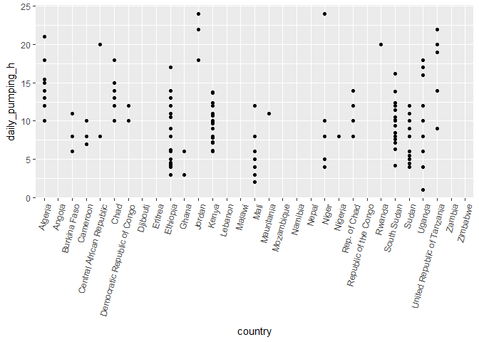

```r
(plot_country_pumping <- borehole_access_restricted %>%
  ggplot(aes(country, daily_pumping_h)) +
  geom_point() +
  theme(axis.text.x = element_text(angle = 75, hjust = 1)))
```

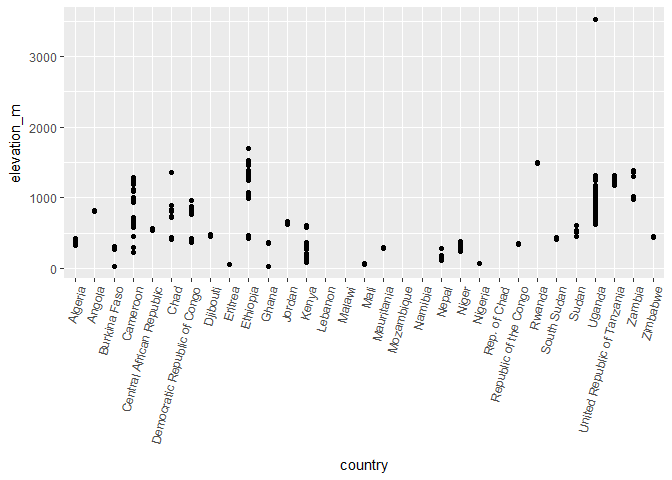

```r
(plot_country_elev <- borehole_access_restricted %>%
  ggplot(aes(country, elevation_m)) +
  geom_point() +
  theme(axis.text.x = element_text(angle = 75, hjust = 1)))
```

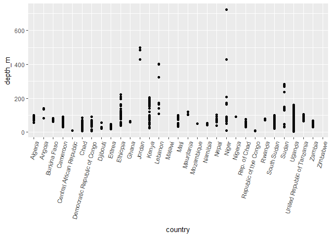

```r
(plot_country_depth <- borehole_access_restricted %>%
  ggplot(aes(country, depth_m)) +
  geom_point() +
  theme(axis.text.x = element_text(angle = 75, hjust = 1)))
```

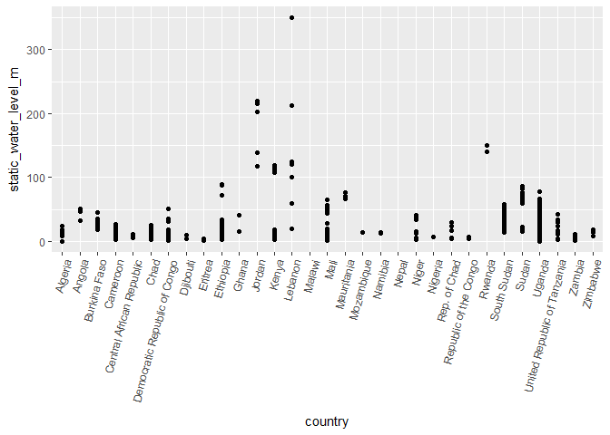

```r
(plot_country_staticlevel <- borehole_access_restricted %>%
  ggplot(aes(country, static_water_level_m)) +
  geom_point() +
  theme(axis.text.x = element_text(angle = 75, hjust = 1)))
```

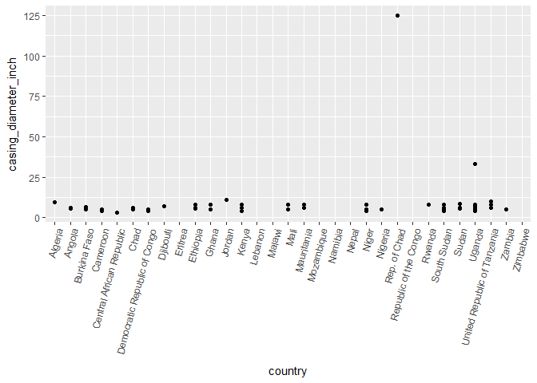

```r
(plot_country_casingdiam <- borehole_access_restricted %>%
  ggplot(aes(country, casing_diameter_inch)) +
  geom_point() +
  theme(axis.text.x = element_text(angle = 75, hjust = 1)))
```

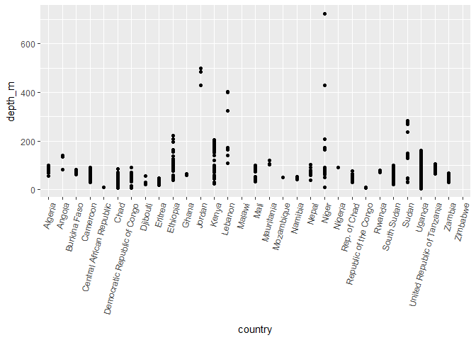

```r
(plot_country_depth <- borehole_access_restricted %>%
  ggplot(aes(country, depth_m)) +
  geom_point() +
  theme(axis.text.x = element_text(angle = 75, hjust = 1)))
```

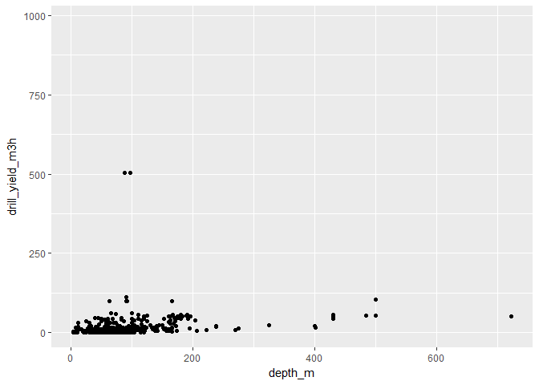

```r
### explore relationships between borehole variables - depth through daily pumping
(plot_depth_drillyield <- borehole_access_restricted %>%
  ggplot(aes(depth_m, drill_yield_m3h)) +
  geom_point())
```

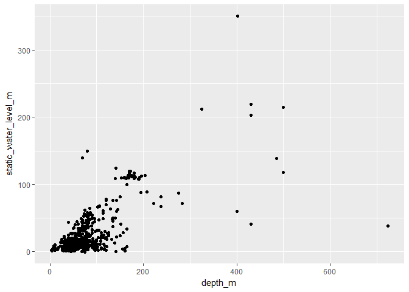

```r
(plot_depth_staticwater <- borehole_access_restricted %>%
  ggplot(aes(depth_m, static_water_level_m)) +
  geom_point())
```

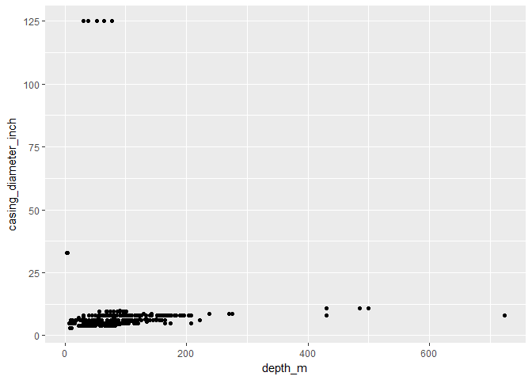

```r
(plot_depth_casing <- borehole_access_restricted %>%
  ggplot(aes(depth_m, casing_diameter_inch)) +
  geom_point())
```

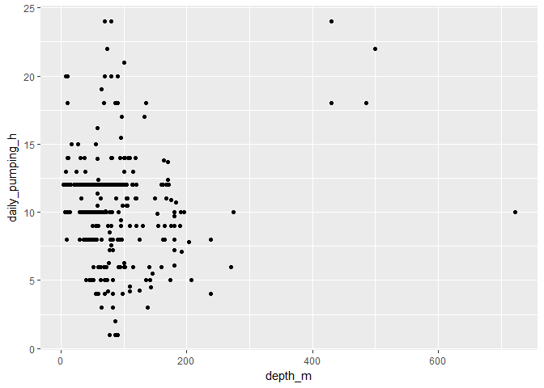

```r
(plot_depth_pumping <- borehole_access_restricted %>%
  ggplot(aes(depth_m, daily_pumping_h)) +
  geom_point())
```

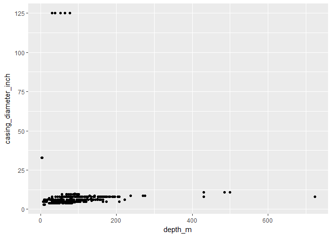

```r
(plot_depth_casing <- borehole_access_restricted %>%
  ggplot(aes(depth_m, casing_diameter_inch)) +
  geom_point())
```

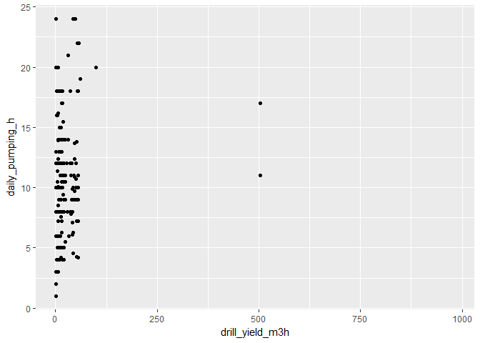

```r
(plot_drill_pump <- borehole_access_restricted %>%
  ggplot(aes(drill_yield_m3h, daily_pumping_h)) +
  geom_point())
```

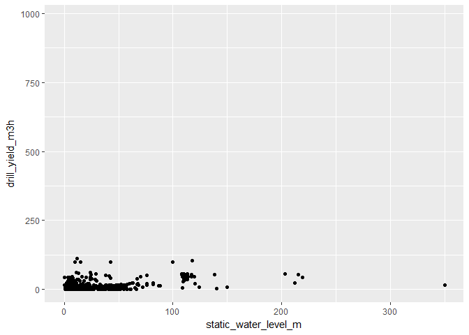

```r
(plot_static_drill <- borehole_access_restricted %>%
  ggplot(aes(static_water_level_m, drill_yield_m3h)) +
  geom_point())
```

### Camp usage

796 observations. Same criteria as above - look at variables with approx < 50% NA’s.

Variables of interest:

- COUNTRY NAME
- EMERGENCY / POST-EMERGENCY
- AVERAGE # LITERS OF POTABLE WATER AVAILABLE PER PERSON PER DAY
- NUMBER OF PERSONS PER USABLE WATER TAP
- % OF WATER QUALITY TESTS AT CHLORINATED COLLECTION LOCATIONS WITH FRC IN THE RANGE 0.2-2MG/L AND TURBIDITY <5NTU5
- NUMBER OF PERSONS PER TOILET/LATRINE
- NUMBER OF PERSONS PER BATH SHELTER/SHOWER
- NUMBER OF PERSONS PER HYGIENE PROMOTER
- REFUGEE POPULATION

```r
summary(camp_usage)
```

```
##    FORM ID           DATE START           DATE END
##  Length:796         Length:796         Min.   :2015-12-31
##  Class :character   Class :character   1st Qu.:2019-02-03
##  Mode  :character   Mode  :character   Median :2019-04-28
##                                        Mean   :2019-03-13
##                                        3rd Qu.:2019-06-30
##                                        Max.   :2019-12-31
##                                        NA's   :2
##   LOCATION ID     LOCATION NAME      COUNTRY NAME
##  Min.   : 209.0   Length:796         Length:796
##  1st Qu.: 486.0   Class :character   Class :character
##  Median : 541.0   Mode  :character   Mode  :character
##  Mean   : 895.9
##  3rd Qu.: 600.0
##  Max.   :4308.0
##  NA's   :2
##  EMERGENCY / POST-EMERGENCY
##  Length:796
##  Class :character
##  Mode  :character
##
##
##
##
##  NUMBER OF PERSONS PER USABLE HANDPUMP / WELL / SPRING
##  Min.   :   0
##  1st Qu.: 250
##  Median : 620
##  Mean   :1254
##  3rd Qu.:1145
##  Max.   :8196
##  NA's   :581
##  NUMBER OF PERSONS PER USABLE WATER TAP
##  Min.   :    1.0
##  1st Qu.:   61.0
##  Median :   99.0
##  Mean   :  213.2
##  3rd Qu.:  163.0
##  Max.   :13576.0
##  NA's   :281
```

[output cut: 105 more lines]

```
##  Min.   :  5.00
##  1st Qu.: 48.00
##  Median : 74.00
##  Mean   : 66.83
##  3rd Qu.: 89.00
##  Max.   :100.00
##  NA's   :723
##  REPORTING PERIOD - ANNUAL INDICATOR
##  Min.   :2015-03-01
##  1st Qu.:2017-04-16
##  Median :2018-09-01
##  Mean   :2018-02-12
##  3rd Qu.:2018-11-01
##  Max.   :2019-05-01
##  NA's   :721
```

```r
glimpse(camp_usage)
```

```
## Observations: 796
## Variables: 25
## $ `FORM ID`                                                                                                           <chr> ...
## $ `DATE START`                                                                                                        <chr> ...
## $ `DATE END`                                                                                                          <date> ...
## $ `LOCATION ID`                                                                                                       <int> ...
## $ `LOCATION NAME`                                                                                                     <chr> ...
## $ `COUNTRY NAME`                                                                                                      <chr> ...
## $ `EMERGENCY / POST-EMERGENCY`                                                                                        <chr> ...
## $ `NUMBER OF PERSONS PER USABLE HANDPUMP / WELL / SPRING`                                                             <int> ...
## $ `NUMBER OF PERSONS PER USABLE WATER TAP`                                                                            <int> ...
## $ `AVERAGE # LITERS OF POTABLE WATER AVAILABLE PER PERSON PER DAY`                                                    <int> ...
## $ `% WATER QUALITY TESTS AT NON CHLORINATED WATER COLLECTION LOCATIONS WITH 0 CFU/100ML`                              <int> ...
## $ `% OF WATER QUALITY TESTS AT CHLORINATED COLLECTION LOCATIONS WITH FRC IN THE RANGE 0.2-2MG/L AND TURBIDITY <5NTU5` <int> ...
## $ `NUMBER OF PERSONS PER TOILET/LATRINE`                                                                              <int> ...
## $ `NUMBER OF PERSONS PER BATH SHELTER/SHOWER`                                                                         <int> ...
## $ `NUMBER OF PERSONS PER HYGIENE PROMOTER`                                                                            <int> ...
## $ `REFUGEE POPULATION`                                                                                                <int> ...
## $ `REPORTING PERIOD - MONTHLY INDICATOR`                                                                              <date> ...
## $ `AVERAGE # L/P/D OF POTABLE WATER COLLECTED AT HOUSEHOLD LEVEL`                                                     <dbl> ...
## $ `% HOUSEHOLDS WITH AT LEAST 10 LITERS/PERSON POTABLE WATER STORAGE CAPACITY`                                        <dbl> ...
## $ `% HOUSEHOLDS COLLECTING DRINKING WATER FROM PROTECTED/TREATED SOURCES`                                             <dbl> ...
## $ `% HOUSEHOLDS WITH HOUSEHOLD TOILET/LATRINE`                                                                        <dbl> ...
## $ `% HOUSEHOLDS REPORTING DEFECATING IN A TOILET`                                                                     <dbl> ...
## $ `% HOUSEHOLDS WITH ACCESS TO SOAP`                                                                                  <dbl> ...
## $ `% HOUSEHOLDS WITH ACCESS TO SOLID WASTE DISPOSAL FACILITY`                                                         <dbl> ...
## $ `REPORTING PERIOD - ANNUAL INDICATOR`                                                                               <date> ...
```

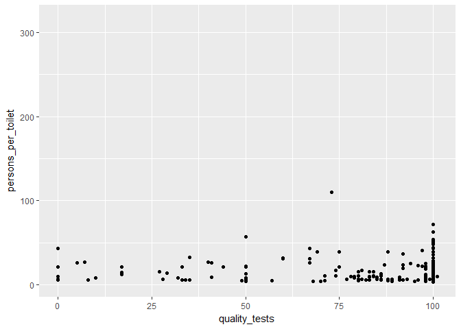

```r
# restrict to vars of interest and rename
camp_usage_restricted <- camp_usage %>%
  select("COUNTRY NAME",
         "EMERGENCY / POST-EMERGENCY",
         "AVERAGE # LITERS OF POTABLE WATER AVAILABLE PER PERSON PER DAY",
         "NUMBER OF PERSONS PER USABLE WATER TAP",
         "% OF WATER QUALITY TESTS AT CHLORINATED COLLECTION LOCATIONS WITH FRC IN THE RANGE 0.2-2MG/L AND TURBIDITY <5NTU5",
         "NUMBER OF PERSONS PER TOILET/LATRINE",
         "NUMBER OF PERSONS PER BATH SHELTER/SHOWER",
         "NUMBER OF PERSONS PER HYGIENE PROMOTER",
         "REFUGEE POPULATION") %>%
  rename(country = "COUNTRY NAME",
         emergency_status = "EMERGENCY / POST-EMERGENCY",
         water_per_person_l = "AVERAGE # LITERS OF POTABLE WATER AVAILABLE PER PERSON PER DAY",
         persons_per_tap = "NUMBER OF PERSONS PER USABLE WATER TAP",
         quality_tests = "% OF WATER QUALITY TESTS AT CHLORINATED COLLECTION LOCATIONS WITH FRC IN THE RANGE 0.2-2MG/L AND TURBIDITY <5NTU5",
         persons_per_toilet = "NUMBER OF PERSONS PER TOILET/LATRINE",
         persons_per_shower = "NUMBER OF PERSONS PER BATH SHELTER/SHOWER",
         persons_per_hygienepromoter = "NUMBER OF PERSONS PER HYGIENE PROMOTER",
         refugee_population = "REFUGEE POPULATION")

# water quality tests vs other vars
(plot_tests_toilet <- camp_usage_restricted %>%
  ggplot(aes(quality_tests, persons_per_toilet)) +
  geom_point())
```

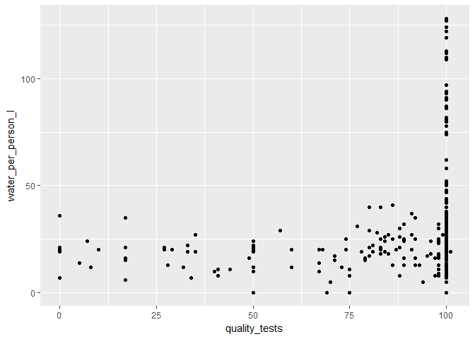

```r
(plot_tests_water <- camp_usage_restricted %>%
  ggplot(aes(quality_tests, water_per_person_l)) +
  geom_point())
```

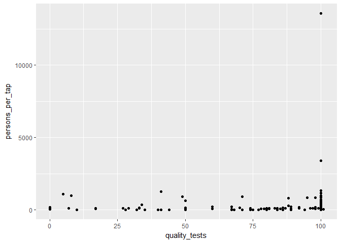

```r
(plot_tests_tap <- camp_usage_restricted %>%
  ggplot(aes(quality_tests, persons_per_tap)) +
  geom_point())
```

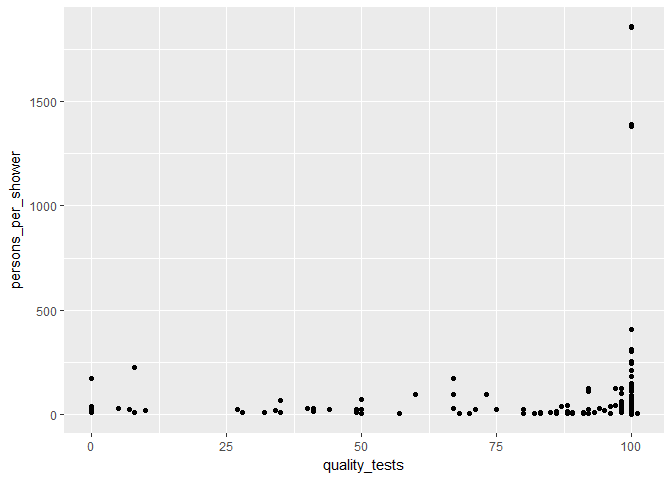

```r
(plot_tests_shower <- camp_usage_restricted %>%
  ggplot(aes(quality_tests, persons_per_shower)) +
  geom_point())
```

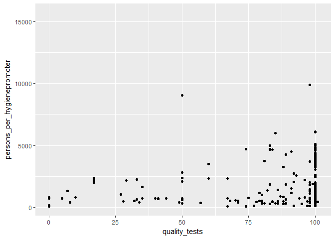

```r
(plot_tests_hygiene <- camp_usage_restricted %>%
  ggplot(aes(quality_tests, persons_per_hygienepromoter)) +
  geom_point())
```

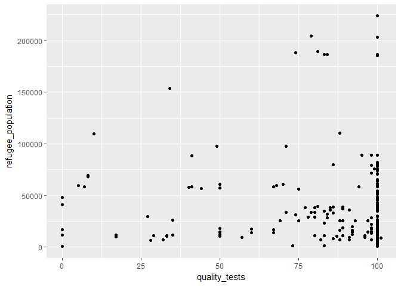

```r
(plot_tests_pop <- camp_usage_restricted %>%
  ggplot(aes(quality_tests, refugee_population)) +
  geom_point())
```

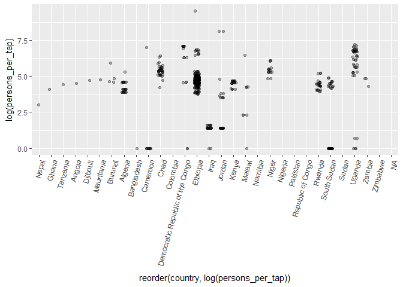

```r
# plotting the distributions of water per person, ppl per tap etc by country would be illustrative when compared with US
# measure water resource crowdedness by country - persons per xyz with additional measure for water per person
(plot_country_tap <- camp_usage_restricted %>%
  ggplot(aes(reorder(country, log(persons_per_tap)), log(persons_per_tap))) +
  geom_jitter(position = position_jitter(w = .2),
              alpha = .3) +
  theme(axis.text.x = element_text(angle = 75, hjust = 1)))
```

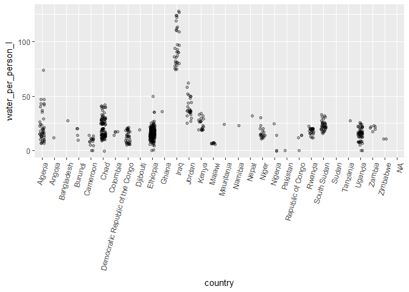

```r
(plot_country_water <- camp_usage_restricted %>%
  ggplot(aes(country, water_per_person_l)) +
  geom_jitter(position = position_jitter(w = .2),
              alpha = .3) +
  theme(axis.text.x = element_text(angle = 75, hjust = 1)))
```

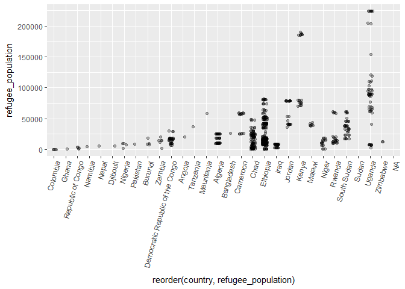

```r
(plot_country_pop <- camp_usage_restricted %>%
  ggplot(aes(reorder(country, refugee_population), refugee_population)) +
  geom_jitter(position = position_jitter(w = .2),
              alpha = .3) +
  theme(axis.text.x = element_text(angle = 75, hjust = 1)))
```

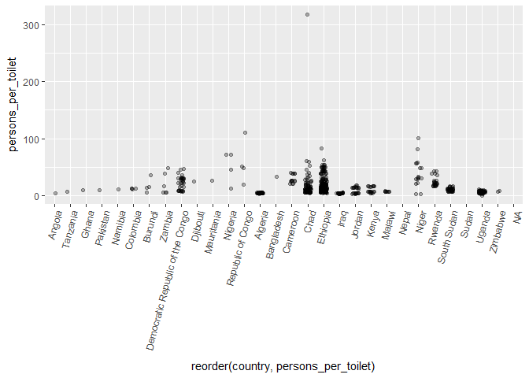

```r
(plot_country_toilet <- camp_usage_restricted %>%
  ggplot(aes(reorder(country, persons_per_toilet), persons_per_toilet)) +
  geom_jitter(position = position_jitter(w = .2),
              alpha = .3) +
  theme(axis.text.x = element_text(angle = 75, hjust = 1)))
```

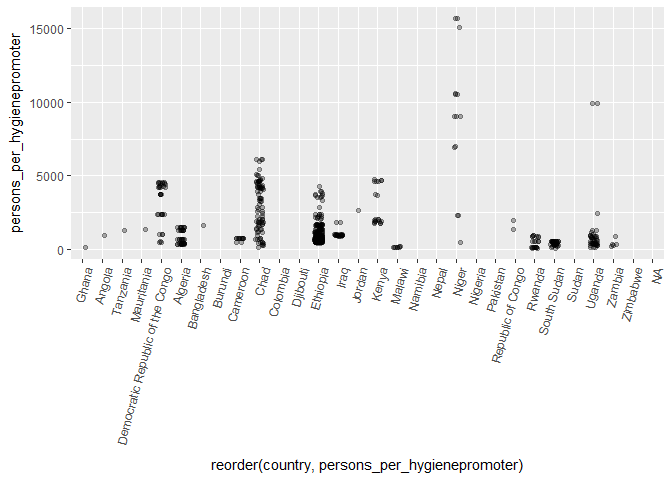

```r
(plot_country_hygiene <- camp_usage_restricted %>%
  ggplot(aes(reorder(country, persons_per_hygienepromoter), persons_per_hygienepromoter)) +
  geom_jitter(position = position_jitter(w = .2),
              alpha = .3) +
  theme(axis.text.x = element_text(angle = 75, hjust = 1)))
```

### US usage

with the exception of 4 NA’s (out of 3223 total observations) in DO-PSPCp, dataset is complete.

rename variables to make them more intuitive

from the data dictionary this is what they mean

STATE State postal abbreviation STATEFIPS State FIPS code COUNTY County name COUNTYFIPS County FIPS code FIPS Concatenated State-county FIPS code YEAR Year of data=2015 TP-TotPop Total population of county, in thousands DO-SSPop Domestic, self-supplied population, in thousands DO-WGWFr Domestic, self-supplied groundwater withdrawals, fresh, in Mgal/d DO-WSWFr Domestic, self-supplied surface-water withdrawals, fresh, in Mgal/d DO-WFrTo Domestic, total self-supplied withdrawals, fresh, in Mgal/d DO-SSPCp Domestic, self-supplied per capita use, in gallons/day [DO-WFrTo/DO-SSPop*1000] DO-PSDel Domestic, deliveries from Public Supply, in Mgal/d DO-PSPCp Domestic, publicly supplied per capita use, in gallons/day [DO-PSDel/PS-TOPop] DO-WDelv Domestic, total use (withdrawals + deliveries), in Mgal/d

Don’t need anything with FIPS

```r
summary(us_usage)
```

```
##     STATE            STATEFIPS            COUNTY
##  Length:3223        Length:3223        Length:3223
##  Class :character   Class :character   Class :character
##  Mode  :character   Mode  :character   Mode  :character
##
##
##
##
##   COUNTYFIPS            FIPS                YEAR        TP-TotPop
##  Length:3223        Length:3223        Min.   :2015   Min.   :    0.089
##  Class :character   Class :character   1st Qu.:2015   1st Qu.:   11.236
##  Mode  :character   Mode  :character   Median :2015   Median :   25.963
##                                        Mean   :2015   Mean   :  100.844
##                                        3rd Qu.:2015   3rd Qu.:   66.707
##                                        Max.   :2015   Max.   :10170.292
##
##     DO-SSPop          DO-WGWFr          DO-WSWFr          DO-WFrTo
##  Min.   :  0.000   Min.   : 0.0000   Min.   :0.00000   Min.   : 0.000
##  1st Qu.:  1.202   1st Qu.: 0.1000   1st Qu.:0.00000   1st Qu.: 0.100
##  Median :  4.885   Median : 0.3900   Median :0.00000   Median : 0.400
##  Mean   : 13.187   Mean   : 0.9963   Mean   :0.01523   Mean   : 1.011
##  3rd Qu.: 14.373   3rd Qu.: 1.0700   3rd Qu.:0.00000   3rd Qu.: 1.085
##  Max.   :277.375   Max.   :22.1900   Max.   :7.44000   Max.   :22.190
##
##    DO-SSPCp            DO-PSDel          DO-PSPCp          DO-WDelv
##  Length:3223        Min.   :  0.000   Min.   :   2.00   Min.   :  0.010
##  Class :character   1st Qu.:  0.580   1st Qu.:  66.00   1st Qu.:  0.920
##  Mode  :character   Median :  1.460   Median :  79.00   Median :  2.090
##                     Mean   :  7.227   Mean   :  87.39   Mean   :  8.239
##                     3rd Qu.:  4.070   3rd Qu.:  93.00   3rd Qu.:  5.515
##                     Max.   :817.880   Max.   :1429.00   Max.   :820.290
##                                       NA's   :4
```

```r
glimpse(us_usage)
```

```
## Observations: 3,223
## Variables: 15
## $ STATE       <chr> "AL", "AL", "AL", "AL", "AL", "AL", "AL", "AL", "A...
## $ STATEFIPS   <chr> "01", "01", "01", "01", "01", "01", "01", "01", "0...
## $ COUNTY      <chr> "Autauga County", "Baldwin County", "Barbour Count...
## $ COUNTYFIPS  <chr> "001", "003", "005", "007", "009", "011", "013", "...
## $ FIPS        <chr> "01001", "01003", "01005", "01007", "01009", "0101...
## $ YEAR        <int> 2015, 2015, 2015, 2015, 2015, 2015, 2015, 2015, 20...
## $ `TP-TotPop` <dbl> 55.347, 203.709, 26.489, 22.583, 57.673, 10.696, 2...
## $ `DO-SSPop`  <dbl> 6.349, 28.802, 1.902, 1.636, 12.858, 0.738, 3.348,...
## $ `DO-WGWFr`  <dbl> 0.38, 2.14, 0.12, 0.16, 0.86, 0.07, 0.27, 0.44, 0....
## $ `DO-WSWFr`  <dbl> 0, 0, 0, 0, 0, 0, 0, 0, 0, 0, 0, 0, 0, 0, 0, 0, 0,...
## $ `DO-WFrTo`  <dbl> 0.38, 2.14, 0.12, 0.16, 0.86, 0.07, 0.27, 0.44, 0....
## $ `DO-SSPCp`  <chr> "60", "74", "63", "98", "67", "95", "81", "71", "5...
## $ `DO-PSDel`  <dbl> 2.71, 12.78, 1.42, 1.81, 2.79, 0.89, 1.35, 7.52, 1...
## $ `DO-PSPCp`  <int> 55, 73, 58, 86, 62, 89, 80, 69, 67, 61, 64, 50, 67...
## $ `DO-WDelv`  <dbl> 3.09, 14.92, 1.54, 1.97, 3.65, 0.96, 1.62, 7.96, 2...
```

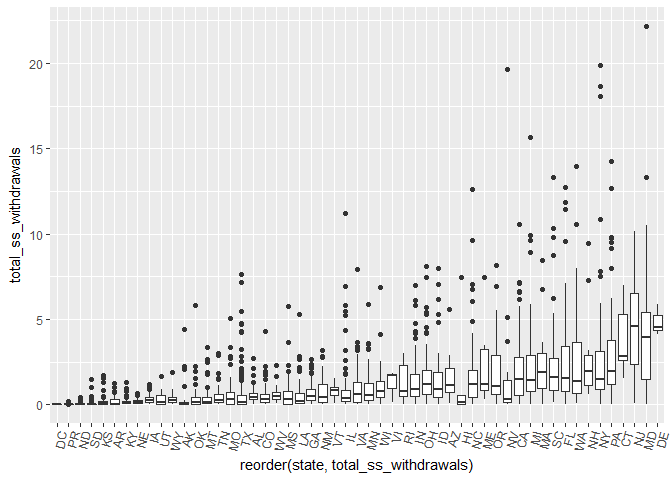

```r
us_usage_restricted <- us_usage %>%
  select(-c(STATEFIPS, COUNTYFIPS, FIPS)) %>%
  rename(state = STATE,
         county = COUNTY,
         year = YEAR,
         countypop = "TP-TotPop",
         ss_pop = "DO-SSPop",
         ss_ground_withdrawals = "DO-WGWFr",
         ss_surface_withdrawals = "DO-WSWFr",
         total_ss_withdrawals = "DO-WFrTo",
         ss_percap_use = "DO-SSPCp",
         del_from_publicsupply = "DO-PSDel",
         pubsupplied_percap_use = "DO-PSPCp",
         totaluse_with_del = "DO-WDelv")

(plot_state_totalsswithdrawals <- us_usage_restricted %>%
  ggplot(aes(reorder(state, total_ss_withdrawals), total_ss_withdrawals)) +
  geom_boxplot() +
  theme(axis.text.x = element_text(angle = 75, hjust = 1)))
```

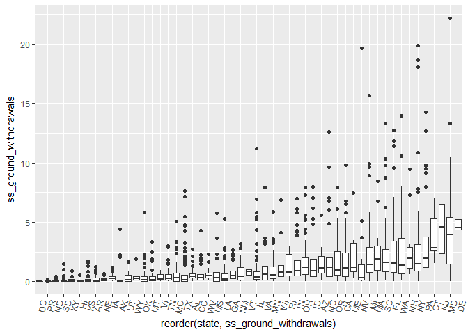

```r
(plot_state_ssgroundwithdrawals <- us_usage_restricted %>%
  ggplot(aes(reorder(state, ss_ground_withdrawals), ss_ground_withdrawals)) +
  geom_boxplot() +
  theme(axis.text.x = element_text(angle = 75, hjust = 1)))
```

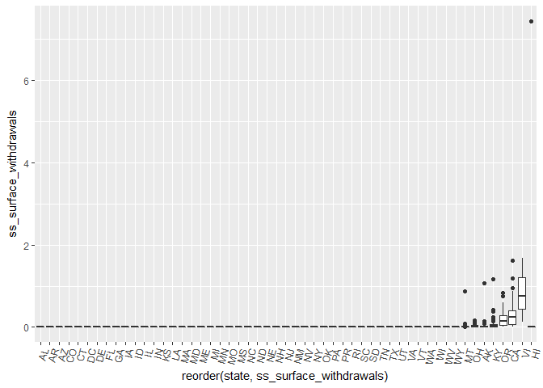

```r
(plot_state_sssurfacewithdrawals <- us_usage_restricted %>%
  ggplot(aes(reorder(state, ss_surface_withdrawals), ss_surface_withdrawals)) +
  geom_boxplot() +
  theme(axis.text.x = element_text(angle = 75, hjust = 1)))
```

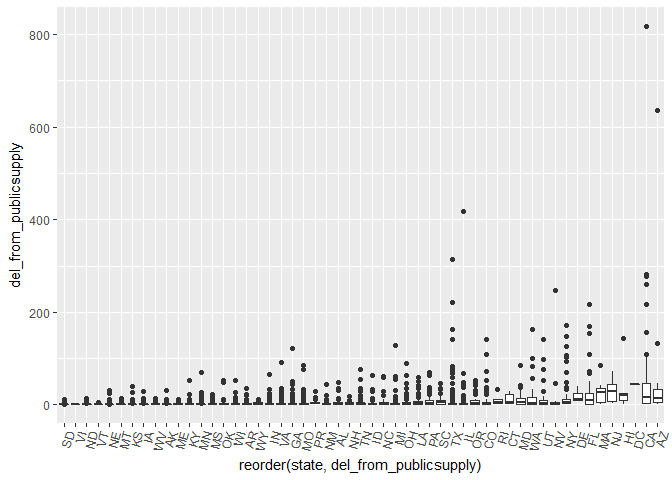

```r
(plot_state_delpubsupp <- us_usage_restricted %>%
  ggplot(aes(reorder(state, del_from_publicsupply), del_from_publicsupply)) +
  geom_boxplot() +
  theme(axis.text.x = element_text(angle = 75, hjust = 1)))
```